# Project 2C: Draft of Notebook

### Scientific Question: How structurally similar are the BRCA1 proteins, known for tumor suppression in breast cancer, in humans and their closest related primate, the chimpanzee?

The brca gene is the breast cancer gene and it produces proteins that help repair damaged dna. The closest related primate to humans are the chimp and they do not have creast cancer as often as humans even though they have the BRCA gene in there body.

### Scientific Hypothesis: If BRCA1 proteins found in humans and chimpanzees are the reason for a different amount of cancer rates found between the two primates, then they will be genetically and structurally different.

We will be looking at the pairwise sequence and the 3d structure of the brca gene in humans and chimps to see if there is a similarity or difference between the two that may explain why humans have a higher rate of breast cancer compared to other primates that also have this gene.

### Load Packages:

Biopython:Bipython is a module that allows us to deal with biological data in python.

Logomaker: logomaker is a python package that generates publication sequence logos. This package can make standard and high customized logos that can show the properties of DNA, RNA, or protein sequences.

NglView: Nglview is an interactive widget that allows us to see molecular structures and trajectories.

BioSeq: the bioseq module provides objects to represent biological sequences with alphabets.

### Part 2A: Load in the data from NCBI and perform Pairwise Alignment

Below is code that runs a pairwise alignment between the human BRCA1 gene sequence and the Chimp BRCA1 sequence and prints the alignment after reading in the two fasta files that were found on the NCBI website.

```python
# Code modified from Geeks for Geeks Pairwise alignment
# Import libraries
from Bio import Align, SeqIO
from Bio.Seq import Seq

# Create function that returns a Sequence
def getSeq(filePath, length=20):
    # local variable
    # call method SeqIO.parse to read in the fasta file of input gene sequence and it takes in the path to the file
    # and the type of file it returns a seqrec iterator
    sequence_record = list(SeqIO.parse(filePath, "fasta"))[0]
    return sequence_record.seq[0:length]


# Get Human Seq
# global variable
# call our getSeq method with our human gene data set to get a sequence
human_seq = getSeq("BRCA1_datasets_Human/ncbi_dataset/data/gene_Human.fna")

# Get Chimp-arooni Seq
# global variable
# call our getSeq method with our human gene data set to get a sequence
chimp_seq = getSeq("BRCA1_datasets_Chimp/ncbi_dataset/data/gene_Chimp.fna")


# Calling method
# prepare pairwise aligner object and save it to a global variable called aligner
aligner = Align.PairwiseAligner()

# Showing method attributes
print(aligner)

# Finding similarities
# use aligner and call method called align that passes in both of the sequences (human and chimp) and returns
# a list of alignments
alignments = aligner.align(human_seq, chimp_seq)

# Showing results
# small for loop that prints each alignment in alignments
for alignment in alignments:
    print(alignment)
```

[output not shown]

[output cut: 28321 more lines]

[output not shown]

### Part 2B: Load in Data from pdb and perform Structural Bioinformatics

Below is code that uses nglview to show the structure of brca1 downloaded from pdb.

```python
# code modified from Iyer Structural bioinformatics video found on piazza

# import nglview package and bio.PDB
import nglview as nv
from Bio.PDB import *
parser = PDBParser()

#Human BRCA1-A
# create global variable structure that uses parser.get_structure which takes in a file name and file of pdb
# and returns a structure object
structure = parser.get_structure("6GVW", "6GVW.pdb")

# create global variable BRCA1
BRCA1_Human = nv.show_biopython(structure)

# create global variables
residues = structure.get_residues()
model = structure[0]
chain = model["A"]
residue = chain[100]
atom = residue["CA"]

res_list = Selection.unfold_entities(structure, "R")

GLU = chain[64]
ARG = chain[8]

# distance measurement global variables
HIS = chain[31]
ILE = chain[27]

ca1 = GLU["CA"]
ca2 = ARG["CA"]

distance = ca1 - ca2
print("Distance: " + str(distance))

#angle measurement global variables
ARG = chain[14]
LYS = chain[16]
TYR = chain[18]

atom1 = ARG["CA"]
atom2 = LYS["CA"]
atom3 = TYR["CA"]

vector1 = atom1.get_vector()
vector2 = atom2.get_vector()
vector3 = atom3.get_vector()
angle = calc_angle(vector1, vector2, vector3)
print("Angle: " + str(angle))

# torsion angles global variables
GLU = chain[11]
MET = chain[102]
ARG2 = chain[8]
LEU = chain[7]

atom4 = GLU["CA"]
atom5 = MET["CA"]
atom6 = ARG2["CA"]
atom7 = LEU["CA"]

vector1 = atom4.get_vector()
vector2 = atom5.get_vector()
vector3 = atom6.get_vector()
vector4 = atom7.get_vector()
Tangle = calc_dihedral(vector1, vector2, vector3, vector4)
print("torsion angle: " + str(Tangle))
BRCA1_Human
```

```
Distance: 14.343486
Angle: 1.2182613918117016
torsion angle: 2.5771063802260334
```

```python
BRCA1_Human.render_image()
```

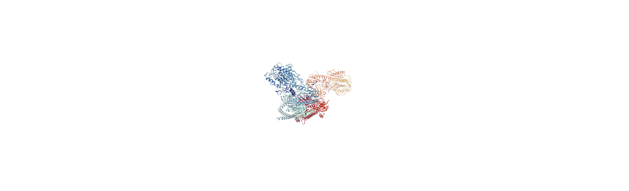

```python
BRCA1_Human._display_image()
```

```python
#install package
pip install logomaker
```

[output not shown]

```
{'seqA': 'GCTGAGACTTCCTGGACGGG', 'seqB': 'AGAGCCCCGAGAGACGCTTG', 'score': 12.0, 'paths': <Path generator object at 0x7fc9729cb770>, 'index': 7089, 'alignment': <Bio.Align.PairwiseAlignment object at 0x7fc9734a26a0>}
```

```
<logomaker.src.Logo.Logo at 0x7fc973488df0>
```

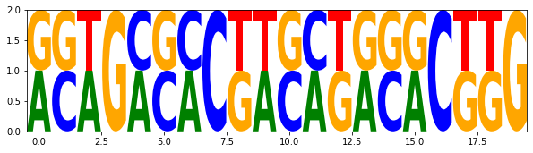

```python
import logomaker as lm

# make an array containing seqA and seqB
raw_seqs = []
raw_seqs.append(alignments.seqA)
raw_seqs.append(alignments.seqB)

#code check
print(vars(alignments))

# iterate over array to align the sequence logos
counts_mat = lm.alignment_to_matrix(raw_seqs)
counts_mat.head()

lm.Logo(counts_mat)
```

```
<logomaker.src.Logo.Logo object at 0x7fc9735fceb0>
```

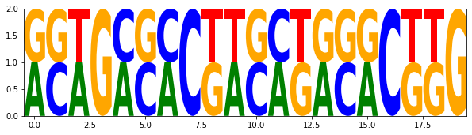

```python
print(lm.Logo(counts_mat))
```

### Analyzing the Results

Based on the first method we did on the two sequences, I cannot say too much because i was not able to run the entire genome without it crashing my computer. I would like to figure out a way i can shorten my genes or more specifically target an aspect of the BRCA1 proteins in both of the human and chimp sequences to more acurately compare the two. The second method, structural bioinfomatics needs some help also. I need to find a sequences within the chimp or change my hypothesis so that i am able to properly find a 3d structure i can compare between the two. Lastly, my sequnce logo tells me whic of the two sequenes are the same between the first interation of the chimp and human. I am not sure how much that will help with my results but maybe i will be able to find a consensus sequence and show how similar they are. I was unsure of what i can do with my project for the visualization.